# Stroop Notebook

# Stroop PRE DATA ANALYSIS

N=56 (Control+Experimental) There is a 3rd undefined group for those that have completed this task, but have dropped out for one reason or another.

## Data Prep

Getting the Data ready for analysis Defaults: R uses dummy coding as it’s default. In this sample, the control group and the congruent condition will be the dummy variables in the analysis. So all Estimates are relative to these dummy variables

### Load Requisite R Packages

note: some of these may not actually be used. Step 1) load the necessary libraries

```r
library(ggplot2)
library(lme4)
library(languageR)
library(lmerTest) #give p-values from mixed models
library(influence.ME)
library(plyr) # magic
library(scales) #for making percents on the y-axis of graphs
```

### Read in the dataset (in current directory)

```r
Stroop_data = read.table("Stroop_R_format.csv", header = TRUE, sep = ",")
```

### Omit missing data (e.g. from practice trials)

```r
Stroop_data = na.omit(Stroop_data)
head(Stroop_data, n = 20)
```

### Omit the Undefined group from the data and specify group as a factor

```r
Stroop_data <- subset(Stroop_data,group=="Control" | group=="Experimental")
Stroop_data$group <- factor(Stroop_data$group)
summary(Stroop_data)
contrasts(Stroop_data$group)
```

### Omit the Practice stimtype and specify stimtype as a factor

```r
Stroop_data <- subset(Stroop_data,stimtype=="Congruent" | stimtype=="Incongruent" | stimtype=="Neutral")
Stroop_data$stimtype <- factor(Stroop_data$stimtype)
summary(Stroop_data)
contrasts(Stroop_data$stimtype)
```

### Isolate the session to the first session

```r
Stroop_data_pre <- subset(Stroop_data, session==1)
Stroop_data_pre$session <- factor(Stroop_data_pre$session)
summary(Stroop_data_pre)
```

### specify subject as a factor

```r
Stroop_data_pre$subject <- as.factor(Stroop_data_pre$subject)

summary(Stroop_data_pre)
```

## Stroop Accuracy Analysis

### Graph Accuracy Data

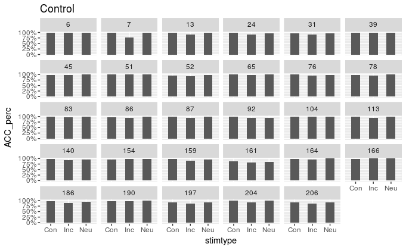

```r
#Control Group Data
Stroop_data_pre_control <- subset(Stroop_data_pre, group=="Control")
#change binary data to a percent
Stroop_data_pre_control_percent <- ddply(Stroop_data_pre_control, .(stimtype, subject), summarize, ACC_perc = mean(ACC))
#Experimental Group Data
Stroop_data_pre_experimental <- subset(Stroop_data_pre, group=="Experimental")
#change binary data to a percent
Stroop_data_pre_experimental_percent <- ddply(Stroop_data_pre_experimental, .(stimtype, subject), summarize, ACC_perc = mean(ACC))
ggplot(data = Stroop_data_pre_control_percent, aes( x = stimtype, y = ACC_perc)) + geom_bar(stat = "identity", width = 0.5) + facet_wrap(~subject) + scale_y_continuous(labels=percent) + scale_x_discrete(labels=c("Con","Inc","Neu")) + ggtitle("Control")
```

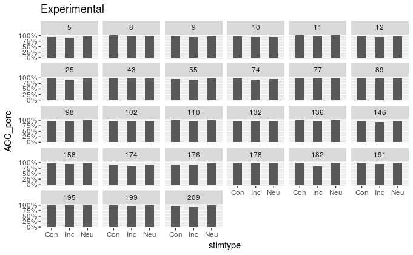

```r
ggplot(data = Stroop_data_pre_experimental_percent, aes( x = stimtype, y = ACC_perc)) + geom_bar(stat = "identity", width = 0.5) + facet_wrap(~subject) + scale_y_continuous(labels=percent) +  scale_x_discrete(labels=c("Con","Inc","Neu")) + ggtitle("Experimental")
```

```r
# Stroop_data_pre_control <- subset(Stroop_data_pre, group=="Control")
# summary(Stroop_data_pre_control)
# Stroop_data_pre_experimental <- subset(Stroop_data_pre, group=="Experimental")
# summary(Stroop_data_pre_experimental)
#
# g1 <- ggplot(data = Stroop_data_pre_control, aes(x = as.numeric(Stroop_data_pre_control$stimtype), y = Stroop_data_pre_control$ACC))
# g2 <- g1 + scale_x_discrete(name = "Stroop Type", limits=c("Con","Inc", "Neu")) + geom_bar(stat = "identity") + facet_wrap(~subject) + ggtitle("Stroop Control ACC") + scale_y_continuous(name = "Number of Correct Responses")
# print(g2)
#
# g1 <- ggplot(data = Stroop_data_pre_experimental, aes(x = as.numeric(Stroop_data_pre_experimental$stimtype), y = Stroop_data_pre_experimental$ACC))
# g2 <- g1 + scale_x_discrete(name = "Stroop Type", limits=c("Con","Inc", "Neu")) + geom_bar(stat = "identity") + facet_wrap(~subject) + ggtitle("Stroop Experimental ACC") + scale_y_continuous(name = "Number of Correct Responses")
# print(g2)
```

**Conclusion**: Subjects have high accuracy accross the board, with some dips for the incongruent condition.

### Model Accuracy (Logit)

```r
Stroop_ACC_model<-glmer(ACC ~ group*stimtype + (1|subject), family=binomial, data=Stroop_data_pre, verbose=TRUE)
```

[output not shown]

```r
summary(Stroop_ACC_model)
```

```
Generalized linear mixed model fit by maximum likelihood (Laplace Approximation) ['glmerMod']
 Family: binomial  ( logit )
Formula: ACC ~ group * stimtype + (1 | subject)
   Data: Stroop_data_pre

     AIC      BIC   logLik deviance df.resid
  7163.9   7220.6  -3575.0   7149.9    24185

Scaled residuals:
     Min       1Q   Median       3Q      Max
-14.5211   0.1170   0.1582   0.2115   0.5551

Random effects:
 Groups  Name        Variance Std.Dev.
 subject (Intercept) 0.6072   0.7792
Number of obs: 24192, groups:  subject, 56

Fixed effects:
                                      Estimate Std. Error z value Pr(>|z|)
(Intercept)                            3.93615    0.17876  22.020   <2e-16 ***
groupExperimental                      0.06694    0.25851   0.259    0.796
stimtypeIncongruent                   -1.05992    0.11641  -9.105   <2e-16 ***
stimtypeNeutral                       -0.03870    0.13780  -0.281    0.779
groupExperimental:stimtypeIncongruent  0.06973    0.17215   0.405    0.685
groupExperimental:stimtypeNeutral      0.08623    0.20557   0.419    0.675
---
Signif. codes:  0 ‘***’ 0.001 ‘**’ 0.01 ‘*’ 0.05 ‘.’ 0.1 ‘ ’ 1

Correlation of Fixed Effects:
            (Intr) grpExp stmtyI stmtyN grpE:I
grpExprmntl -0.687
stmtypIncng -0.471  0.325
stimtypNtrl -0.393  0.272  0.603
grpExprmn:I  0.318 -0.477 -0.676 -0.408
grpExprmn:N  0.264 -0.397 -0.404 -0.671  0.595
```

**Conclusion**: no group differences (as expected). Participant’s were significantly less accurate in the Incongruent condition (as expected)

## Stroop Reaction Time Analysis

### Format RT data

(subset for RTs when they are accurate, greater than 200ms, and less than 2000 ms) See how many observations are lost when we subset the data

```r
#all observations
print("All Data")
```

```
[1] "All Data"
```

```r
All_data <- length(Stroop_data_pre$RT)
summary(Stroop_data_pre)
```

```
    subject      session            group              stimtype         ACC
 5      :  432   1:24192   Control     :12528   Congruent  :8064   Min.   :0.0000
 6      :  432             Experimental:11664   Incongruent:8064   1st Qu.:1.0000
 7      :  432                                  Neutral    :8064   Median :1.0000
 8      :  432                                                     Mean   :0.9628
 9      :  432                                                     3rd Qu.:1.0000
 10     :  432                                                     Max.   :1.0000
 (Other):21600
       RT
 Min.   :   0.0
 1st Qu.: 759.0
 Median : 915.0
 Mean   : 941.8
 3rd Qu.:1107.0
 Max.   :1897.0
```

```r
#remove innacurate responses
print("Removed innacurate trials (from all data dataframe)")
```

```
[1] "Removed innacurate trials (from all data dataframe)"
```

```r
Stroop_data_pre_RT <- subset(Stroop_data_pre, ACC==1)
All_acc_data <- length(Stroop_data_pre_RT$RT)
summary(Stroop_data_pre_RT)
```

```
    subject      session            group              stimtype         ACC
 11     :  431   1:23291   Control     :12028   Congruent  :7869   Min.   :1
 166    :  431             Experimental:11263   Incongruent:7553   1st Qu.:1
 51     :  430                                  Neutral    :7869   Median :1
 77     :  430                                                     Mean   :1
 89     :  429                                                     3rd Qu.:1
 104    :  429                                                     Max.   :1
 (Other):20711
       RT
 Min.   :  25.0
 1st Qu.: 765.0
 Median : 919.0
 Mean   : 954.6
 3rd Qu.:1108.0
 Max.   :1897.0
```

```r
#remove short and long RTs
print("Removed slow and fast RTs")
```

```
[1] "Removed slow and fast RTs"
```

```r
Stroop_data_pre_RT <- subset(Stroop_data_pre_RT, RT>200 & RT<2000)
filtered_data <- length(Stroop_data_pre_RT$RT)
summary(Stroop_data_pre_RT)
```

```
    subject      session            group              stimtype         ACC
 11     :  431   1:23285   Control     :12024   Congruent  :7866   Min.   :1
 166    :  431             Experimental:11261   Incongruent:7551   1st Qu.:1
 51     :  430                                  Neutral    :7868   Median :1
 77     :  430                                                     Mean   :1
 89     :  429                                                     3rd Qu.:1
 104    :  429                                                     Max.   :1
 (Other):20705
       RT
 Min.   : 252.0
 1st Qu.: 765.0
 Median : 919.0
 Mean   : 954.9
 3rd Qu.:1108.0
 Max.   :1897.0
```

```r
print("Percentage of Data Removed")
```

```
[1] "Percentage of Data Removed"
```

```r
perc_data_rm <- (1 - (filtered_data/All_acc_data) ) * 100
perc_data_rm
```

```
[1] 0.02576102
```

**Conclusion**: barely any data removed from RT filtering. Good to go.

### Graph RT data

Note: just doing it by stimtype since subject data appears to be in good ranges

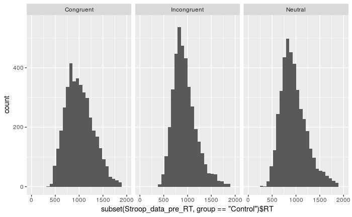

```r
#hist(subset(Stroop_data_pre_RT, group=="Control")$RT,ylim=c(0,1600))
#hist(subset(Stroop_data_pre_RT, group=="Experimental")$RT,ylim=c(0,1600))
ggplot(data = subset(Stroop_data_pre_RT, group=="Control"), aes(subset(Stroop_data_pre_RT, group=="Control")$RT)) + geom_histogram() + facet_wrap(~subset(Stroop_data_pre_RT, group=="Control")$stimtype) + scale_y_continuous(limits = c(0,550)) + scale_x_continuous(limits = c(0,2000))
```

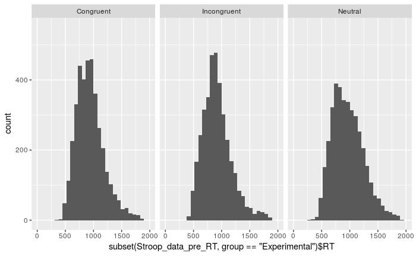

```r
ggplot(data = subset(Stroop_data_pre_RT, group=="Experimental"), aes(subset(Stroop_data_pre_RT, group=="Experimental")$RT)) + geom_histogram() + facet_wrap(~subset(Stroop_data_pre_RT, group=="Experimental")$stimtype) + scale_y_continuous(limits = c(0,550)) + scale_x_continuous(limits = c(0,2000))
```

**Conclusion**: data show a bit of skew, will transform to see if they look better

### Log Transform RT data

```r
Stroop_data_pre_RT$log_RT <- log(1/Stroop_data_pre_RT$RT)
```

### graph logged RT data

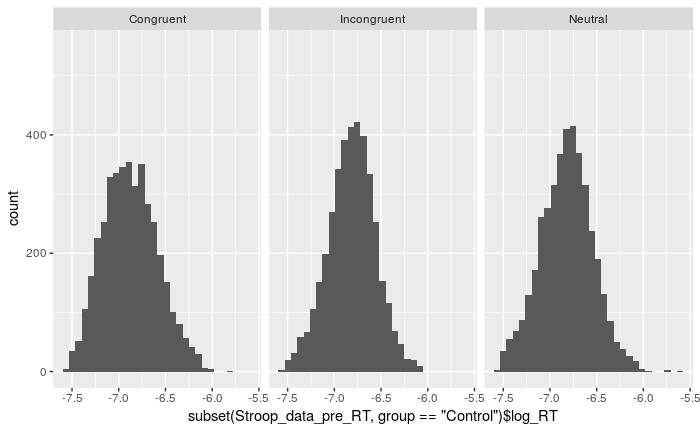

```r
#hist(subset(Stroop_data_pre_RT, group=="Control")$RT,ylim=c(0,1600))
#hist(subset(Stroop_data_pre_RT, group=="Experimental")$RT,ylim=c(0,1600))
ggplot(data = subset(Stroop_data_pre_RT, group=="Control"), aes(subset(Stroop_data_pre_RT, group=="Control")$log_RT)) + geom_histogram() + facet_wrap(~subset(Stroop_data_pre_RT, group=="Control")$stimtype) + scale_y_continuous(limits = c(0,550))
```

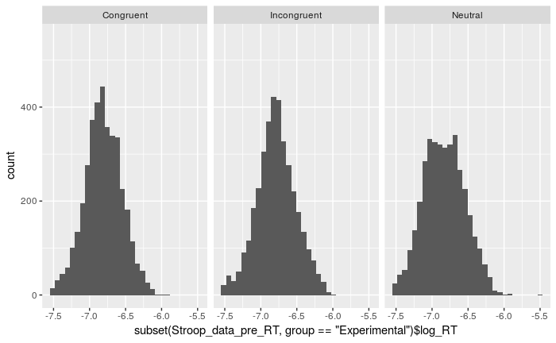

```r
ggplot(data = subset(Stroop_data_pre_RT, group=="Experimental"), aes(subset(Stroop_data_pre_RT, group=="Experimental")$log_RT)) + geom_histogram() + facet_wrap(~subset(Stroop_data_pre_RT, group=="Experimental")$stimtype) + scale_y_continuous(limits = c(0,550))
```

**Conclusion**: This appears to introduce more outliers, I’m going to stick with the untransformed data for analysis

### Model RT by group and stimtype

```r
Stroop_RT_model <- lmer(RT ~ group*stimtype + (1|subject), data = Stroop_data_pre_RT)
summary(Stroop_RT_model)
```

```
Linear mixed model fit by REML
t-tests use  Satterthwaite approximations to degrees of freedom ['lmerMod']
Formula: RT ~ group * stimtype + (1 | subject)
   Data: Stroop_data_pre_RT

REML criterion at convergence: 319835.2

Scaled residuals:
    Min      1Q  Median      3Q     Max
-3.3731 -0.6507 -0.1316  0.5123  4.7322

Random effects:
 Groups   Name        Variance Std.Dev.
 subject  (Intercept) 12979    113.9
 Residual             53556    231.4
Number of obs: 23285, groups:  subject, 56

Fixed effects:
                                       Estimate Std. Error        df t value Pr(>|t|)
(Intercept)                             911.383     21.464    56.000  42.460  < 2e-16 ***
groupExperimental                       -22.679     30.911    56.000  -0.734    0.466
stimtypeIncongruent                     146.786      5.191 23171.000  28.279  < 2e-16 ***
stimtypeNeutral                          31.199      5.132 23171.000   6.079 1.23e-09 ***
groupExperimental:stimtypeIncongruent   -10.646      7.462 23171.000  -1.427    0.154
groupExperimental:stimtypeNeutral        -4.283      7.384 23171.000  -0.580    0.562
---
Signif. codes:  0 ‘***’ 0.001 ‘**’ 0.01 ‘*’ 0.05 ‘.’ 0.1 ‘ ’ 1

Correlation of Fixed Effects:
            (Intr) grpExp stmtyI stmtyN grpE:I
grpExprmntl -0.694
stmtypIncng -0.118  0.082
stimtypNtrl -0.120  0.083  0.494
grpExprmn:I  0.082 -0.118 -0.696 -0.344
grpExprmn:N  0.083 -0.119 -0.344 -0.695  0.495
```

**Conclusions**: No main group effect or interactions (as expected), The incongruent and neutral trials are slower relative to congruent trials (as expected)

### Model log RT by group and stimtype

```r
Stroop_log_RT_model <- lmer(log_RT ~ group*stimtype + (1|subject), data = Stroop_data_pre_RT)
summary(Stroop_log_RT_model)
```

```
Linear mixed model fit by REML
t-tests use  Satterthwaite approximations to degrees of freedom ['lmerMod']
Formula: log_RT ~ group * stimtype + (1 | subject)
   Data: Stroop_data_pre_RT

REML criterion at convergence: -379.6

Scaled residuals:
    Min      1Q  Median      3Q     Max
-3.7835 -0.6096  0.0359  0.6165  5.7418

Random effects:
 Groups   Name        Variance Std.Dev.
 subject  (Intercept) 0.01482  0.1217
 Residual             0.05686  0.2384
Number of obs: 23285, groups:  subject, 56

Fixed effects:
                                        Estimate Std. Error         df  t value Pr(>|t|)
(Intercept)                           -6.777e+00  2.292e-02  5.600e+01 -295.755  < 2e-16 ***
groupExperimental                      2.358e-02  3.300e-02  5.600e+01    0.714    0.478
stimtypeIncongruent                   -1.508e-01  5.348e-03  2.322e+04  -28.199  < 2e-16 ***
stimtypeNeutral                       -3.808e-02  5.288e-03  2.322e+04   -7.202 6.14e-13 ***
groupExperimental:stimtypeIncongruent  8.862e-03  7.688e-03  2.322e+04    1.153    0.249
groupExperimental:stimtypeNeutral      4.181e-03  7.608e-03  2.322e+04    0.550    0.583
---
Signif. codes:  0 ‘***’ 0.001 ‘**’ 0.01 ‘*’ 0.05 ‘.’ 0.1 ‘ ’ 1

Correlation of Fixed Effects:
            (Intr) grpExp stmtyI stmtyN grpE:I
grpExprmntl -0.694
stmtypIncng -0.114  0.079
stimtypNtrl -0.115  0.080  0.494
grpExprmn:I  0.079 -0.114 -0.696 -0.344
grpExprmn:N  0.080 -0.115 -0.344 -0.695  0.495
```

**Conclusion**: Same story as the untransformed data.

## Conclusions

good: No overall group differences in RT and Accuracy

bad: Nothing really, as far as I can tell these data are clean.